# RNA-seq(2)

```r
if (!requireNamespace("BiocManager", quietly = TRUE))
  install.packages("BiocManager")
if (!require("airway", quietly = TRUE)) #使用数据集
  BiocManager::install("airway")
if (!require("org.Hs.eg.db", quietly = TRUE))
  BiocManager::install("org.Hs.eg.db")
if (!require("clusterProfiler", quietly = TRUE))
  BiocManager::install("clusterProfiler")
if (!require("DESeq2", quietly = TRUE)) #差异分析
  BiocManager::install("DESeq2")
```

```r
library(airway)
data(airway)#数据
head(airway)
expr <- assay(airway)
expr[1:5,1:5]
```

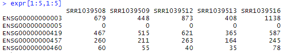

```r
dim(expr)
```

```r
index1=c(rowSums(expr)>0)
class(index1)
exp2=expr[index1,]
dim(exp2)
#此处操作的目的在于将没有read比对上的基因行删去，简洁数据~
```

```r
#获取分组信息
group_list <- colData(airway)$dex
group_list
```

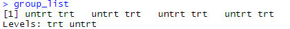

```r
library(DESeq2)
options(stringsAsFactors = F)
#构建dds对象,从表达矩阵countData和样品信息colData构建DESeqDataSet对象
colData <- data.frame(row.names=colnames(expr), group_list=group_list)
colData
dds <- DESeqDataSetFromMatrix(countData = round(exp2,0),colData = colData,design = ~ group_list)
dds
#数据过滤
dds <- dds[rowSums(counts(dds))>1,]#过滤低丰度数据
nrow(dds)
```

### 样本聚类

```r
#用vst来标化数据
vsd <- vst(dds, blind = F)
#再用dist这个函数计算样本间的距离
sampleDists <- dist(t(assay(vsd)))
library(ggplot2)
library(factoextra)
res <- hcut(sampleDists, k = 2, stand = TRUE)
fviz_dend(res,
          # 加边框
          rect = TRUE,
          # 边框颜色
          rect_border="cluster",
          # 边框线条类型
          rect_lty=2,
          # 边框线条粗细
          lwd=1.2,
          # 边框填充
          rect_fill = T,
          # 字体大小
          cex = 1,
          # 字体颜色
          color_labels_by_k=T,
          # 平行放置
          horiz=T)
```

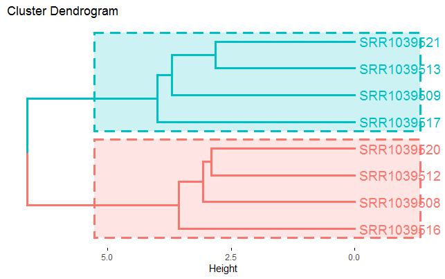

## DESeq2的标准化方法

### （1）计算归一化系数sizeFactor

```r
dds <- estimateSizeFactors(dds)
```

### （2）标准化之后的数据

```r
normalized_counts <- counts(dds,normalized=T)
```

## 差异表达分析

### 第一步：

```r
dds <- DESeq(dds)
```

```r
#提取差异分析结果
res <- results(dds)
resultsNames(dds)
res=results(dds,contrast=c("group_list","trt","untrt"))
plotMA(res,ylim=c(-2,2))
```

[figure not shown]

```r
names（res)
```

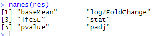

```r
plotMA(res,ylim=c(-2,2))
```

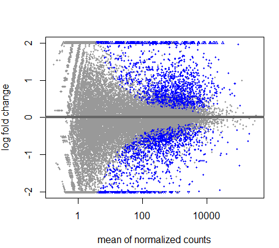

```r
DEG1=as.data.frame(res)
write.csv(x=DEG1,file="res.csv")
```

MA-plot上的点是每一个基因。横坐标是标准化后的counts平均值，纵坐标是log后的变化值。蓝色的点是p.adjust的值小于0.1的基因，由counts函数中的alpha 参数指定。 我们发现在左侧，有很多counts很小的基因，发生了很大的变化，但是没有明显意义。类似于从(1,3,9)变成了（20,12,3）他们的counts很小，波动性很大，对logFC产生了很大的影响。 GSEA分析中，排序就是按照logFC来进行的。按照这个结果往下做，GSEA那里，富集不到任何条目。

那就需要矫正。用的函数是lfcShrink

### LFC校正

这一步，对于依赖logFC变化值的分析，很重要，比如GSEA分析。我们画一个MAplot图，

```r
resultsNames(dds)
dd1 <- lfcShrink(dds, coef="group_list_untrt_vs_trt", type="apeglm")
```

```r
plotMA(dd1,ylim=c(-2,2))
```

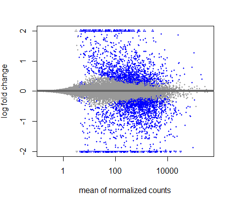

这样，原先那些波动很大的基因，就被矫正了。而此时有LogFC以蓝色的点为主。

```r
names(dd1)
```

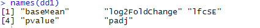

与res相比少了"stat"一列。这一步只会对LFC的值产生影响，p值是没有改变的，不会改变显著差异的基因总数。

### 排序和筛选

```r
res<-dd1
resOrdered=res[order(res$pvalue),] #order函数是给出从小到大排序后的位置(默认升序)
sum(res$padj<0.1, na.rm=TRUE) # na.rm 为remove na值，否则会影响统计量
sum(res$pvalue<0.05, na.rm=TRUE)
sum(!is.na(res$pvalue))
resSig=subset(resOrdered, padj < 0.1 & abs(log2FoldChange) > 1)
dim(resSig)
save(resSig,file="resSig.Rdata")
load(file="resSig.Rdata")
DEG2=as.data.frame(resSig)
write.csv(x=resSig, file = "results.csv")
```

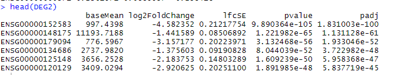

### 热图

根据基因表达矩阵比对上的read数目绘制

这里选取最有意义的50个基因比对read数目为例

```r
library(pheatmap)
choose_gene=head(rownames(DEG2),50)
#根据DEG2结果，提取目标基因名
choose_matrix=exp2[choose_gene,]
choose_matrix=t(scale(t(choose_matrix)))
```

一般绘制热图，都需要对数据进行归一化处理。这里用到了t()转置函数的原因是因为基因表达矩阵表中观测为基因，变量为样本。而scale()归一化函数是针对每一列单独处理的。因为每一个基因的本身情况各不相同，而且我们的目的是基于实验组与对照组的比较来研究基因表达变化，所以需要转置下表达矩阵（观测为样本，变量为基因），然后再进行对每一列的归一化处理；最后再进行一次转置，即得到下图结果。

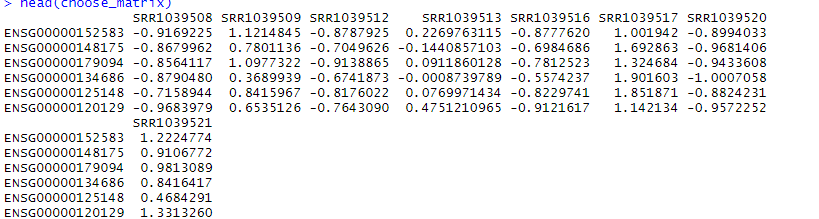

```r
pheatmap(choose_matrix,filename = 'DEG_top50_heatmap.png')
```

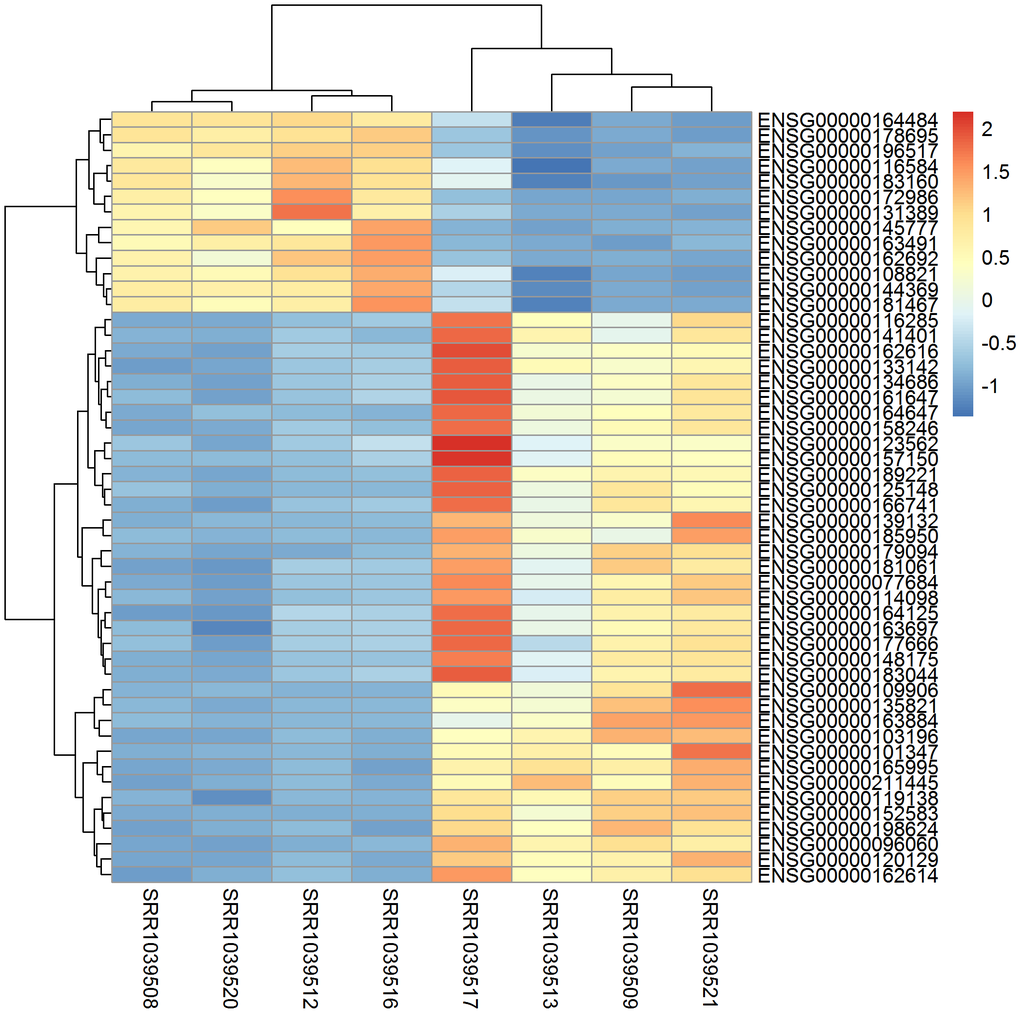

### 火山图

本质上就是根据DEG数据里基因的log2FoldChange与pvalue绘制点图

把点分成三类：上调基因、下调基因与无显著改变基因。

```r
DEG1=na.omit(DEG1)
```

### （1）设置分类判断阈值并增加分类列

```r
logFC_cutoff=with(DEG1,mean(abs(log2FoldChange))+2*sd(abs(log2FoldChange)))
logFC_cutoff
2^logFC_cutoff
DEG1$change=as.factor(ifelse(DEG1$pvalue<0.05 &  abs(DEG1$log2FoldChange)>logFC_cutoff,
                             ifelse(DEG1$log2FoldChange>logFC_cutoff,'UP','DOWN'),'NOT'))
```

### （2）编写图中的注释信息

```r
this_tile=paste('Cutoff for logFC is ',round(logFC_cutoff,3),
                '\nThe number of up gene is ',nrow(DEG1[DEG1$change=='UP',]),
                '\nThe number of down gene is ',nrow(DEG1[DEG1$change=='DOWN',]))
#其中\n为换行符
```

### （3）利用ggplot2绘制火山图

```r
library(ggplot2)
g=ggplot(data=DEG1,
         aes(x=log2FoldChange,y=-log10(pvalue),   #这里将pvalue取负对数
             color=change)) +
  geom_point(alpha=0.4,size=1.75) +     #绘制点图
  theme_set(theme_set(theme_bw(base_size=20))) +
  xlab("log2 fold change")+ylab("-log10 pvalue") +    #轴标签
  ggtitle(this_tile)+theme(plot.title=element_text(size=15,hjust=0.5)) +
  scale_color_manual(values=c('blue','black','red'))   #设定颜色
ggsave(g,filename='volcanoo.png')
```

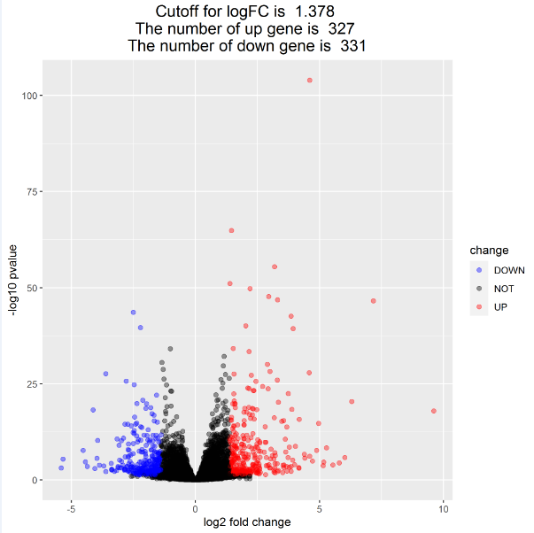

### 把差异分析的结果转化成data.frame的格式

```r
#再把差异分析的结果转化成data.frame的格式
library(dplyr)
library(tibble)
res <- DEG2 %>%
  data.frame() %>%
  rownames_to_column("gene_id")
res
```

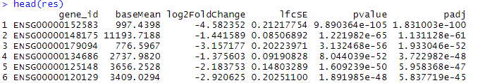

### 基因ID转换

```r
#基因ID转换
library(AnnotationDbi)
library(org.Hs.eg.db)
res$symbol <- mapIds(org.Hs.eg.db,
                     keys=res$gene_id,
                     column="SYMBOL",
                     keytype="ENSEMBL",
                     multiVals="first")
res$entrez <- mapIds(org.Hs.eg.db,
                     keys=res$gene_id,
                     column="ENTREZID",
                     keytype="ENSEMBL",
                     multiVals="first")
head(res)
```

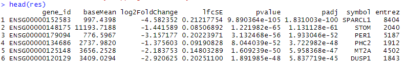

### 制作geneLis

这里GSEA分析是用clusterprofier包. 使用这个包做GSEA，要制作一个genelist，这个是一个向量，他的内容是排序后的logFC值，他的名称是ENTREZID，而这两个我们都是不缺的，在上一步得到的差异结果中。

```r
library(dplyr)
gene_df <- res %>%
  dplyr::select(gene_id,log2FoldChange,symbol,entrez) %>%
  ## 去掉NA
  filter(entrez!="NA") %>%
  ## 去掉重复
  distinct(entrez,.keep_all = T)
```

制作genelist的三部曲

```r
## 1.获取基因logFC
geneList <- gene_df$log2FoldChange
## 2.命名
names(geneList) = gene_df$entrez
## 3.排序很重要
geneList = sort(geneList, decreasing = TRUE)
head(geneList)
```

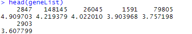

### GSEA分析

```r
#完成KEGG的GSEA分析
library(clusterProfiler)
gseaKEGG <- gseKEGG(geneList     = geneList,

                  organism     = 'hsa',

                  nPerm        = 1000,

                  minGSSize    = 10,

                  pvalueCutoff = 0.9,

                  verbose      = FALSE)
head(gseaKEGG)[,1:6]
gseaKEGG$Description
```

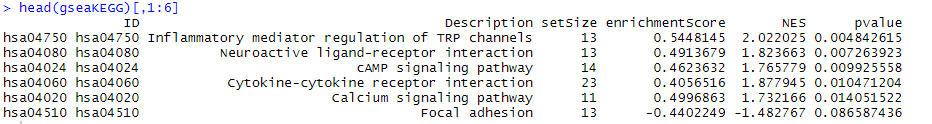

```r
library(ggplot2)
dotplot(gseaKEGG,showCategory=12,split=".sign")+facet_grid(~.sign)
```

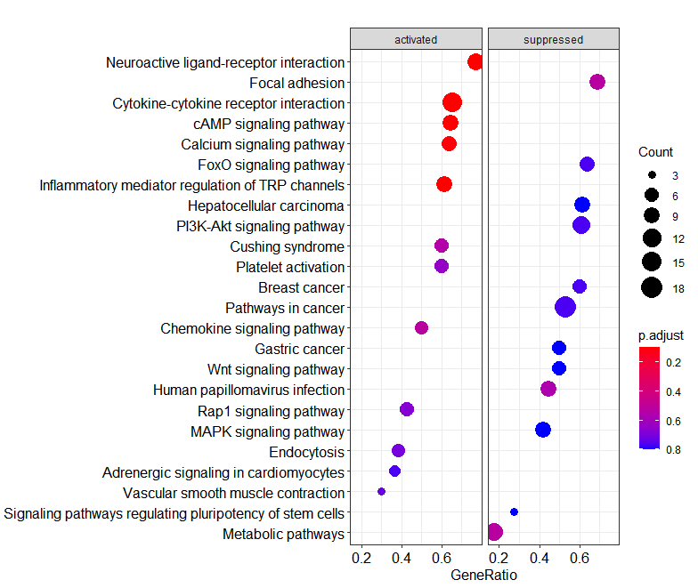

```r
gseaKEGG_results <- gseaKEGG@result
gseaKEGG_results
```

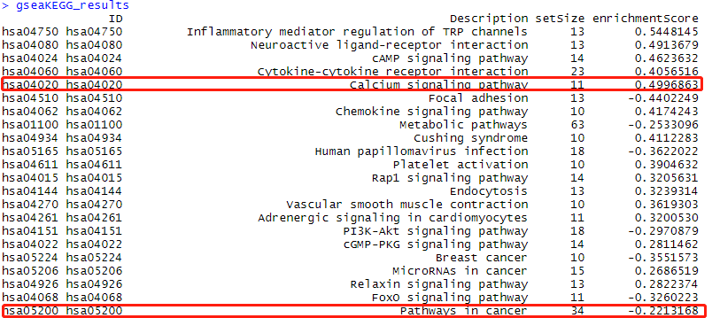

这时候，我们看到有一些通路是被激活的，有一些通路是被抑制的。比如Pathways in cancer是被抑制的，我们可以选取单个通路来作图。 把富集的结果转换成data.frame,找到Pathways in cancer的通路ID是hsa05200.

```r
library(enrichplot)
pathway.id = "hsa05200"
gseaplot2(gseaKEGG,
          color = "red",
          geneSetID = pathway.id,
          pvalue_table = T)
```

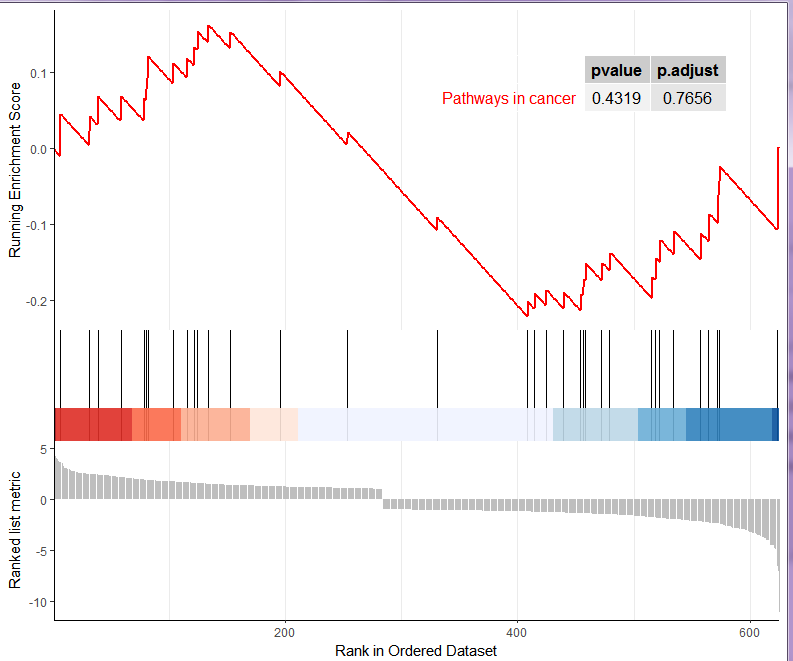

比如Calcium signaling pathway不是被抑制的，我们可以选取单个通路来作图。 把富集的结果转换成data.frame,找到Calcium signaling pathway的通路ID是hsa04020.

```r
library(enrichplot)
pathway.id = "hsa04020"
gseaplot2(gseaKEGG,
          color = "red",
          geneSetID = pathway.id,
          pvalue_table = T)
```

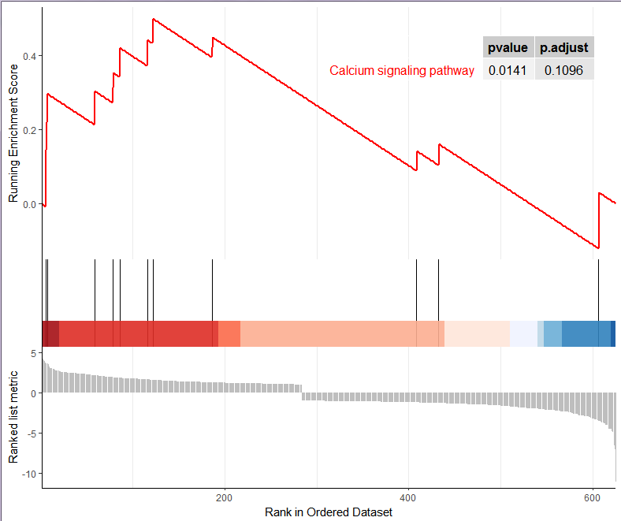